# respR - Measuring intermittent-flow data

2017-09-25

## Introduction

`respR` is an R package that provides a structural, reproducible workflow for the processing and analysis of respirometry-related data.

For users who have already read the introductory vignette, this document provides additional documentation related to the analysis of **intermittent-flow** data.

More information about the package, including additional documentation, can be found on the `respR` page on [GitHub](https://github.com/januarharianto/respR).

## Intermittent-flow respirometry

```
#> O2 :  num [1:4831] 7.17 7.17 7.18 7.16 7.2 7.2 7.16 7.16 7.19 7.18 ...
#> Time :  int [1:4831] 0 1 2 3 4 5 6 7 8 9 ...
#>                  Time O2
#> Length of data   4831 4831
#> Data are numeric
#> NA/NaN
#> Duplicates            X
#> Evenly-spaced         X
#> Note: Integer columns have been converted to numeric.
#> New dataframe generated.
```

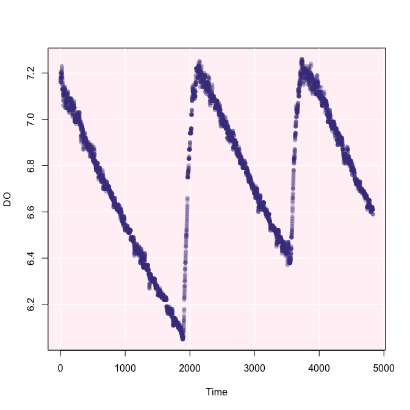

```r
library(respR)
data(intermittent)
# check the data for errors:
check.input(intermittent, plot = T)
```

Analysis of the data would require the user to only use sections of the data where oxygen concentration is decreasing. We can use `calc.rate()` to analyse the sections simultaneously.

By specifying a vector of numbers in the arguments `from` and `to`, the function will recognise that multiple subsets of the data are to be analysed. Subsetting the data is then a matter of matching the vector elements by position.

For example, using the arguments `from = c(200, 2300, 4100)`, and `to = c(1800, 3200, 4600)`, with the method `by = "time"` will analyse the data at 3 subset locations: from between 200 and 1800 s, 2300 and 3200 s, & 4100 and 4600 s. The results are automatically averaged. Weighting the results ensure that the results contribute fairly to the mean value, since the subset lengths tend to differ and should not carry equal weight (i.e. a subset that runs for 20 minutes should not be equal to a subset that runs for 2 minutes).

```r
# calculate rate
rate <- calc.rate(intermittent, from = c(200, 2300, 4100),
  to = c(1800, 3200, 4600), by = 'time')
```

```
#> Data subset is by time.
#> Result are averaged across 3 data subsets, and weighted to time.
```

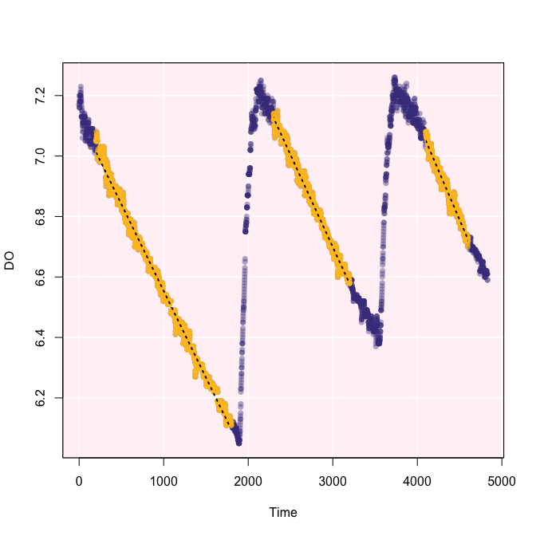

```r
print(rate)
```

```
#> Rate (b1): -0.000598
```

Calling `summary()` will show the coefficients and locations of each subset.

```r
summary(rate)
```

```
#>         b0            b1   rsq from.row to.row from.time to.time from.o2
#> 1 7.127202 -0.0005734109 0.995      201   1801       200    1800    7.05
#> 2 8.528274 -0.0006097325 0.990     2301   3201      2300    3200    7.12
#> 3 9.731918 -0.0006539752 0.967     4101   4601      4100    4600    7.08
#>   to.o2 row.len time.len
#> 1  6.11    1601     1600
#> 2  6.58     901      900
#> 3  6.73     501      500
```

You can also use `plot()` to view the diagnostic plots of any individual subset. The argument `rep` determines the data subset to plot.

```
#> Plotting...this may take a while for large datasets.
```

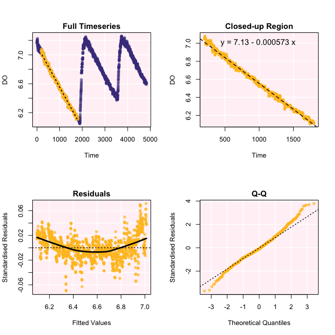

```r
plot(rate)           # view the first subset
```

```
#> Plotting...this may take a while for large datasets.
```

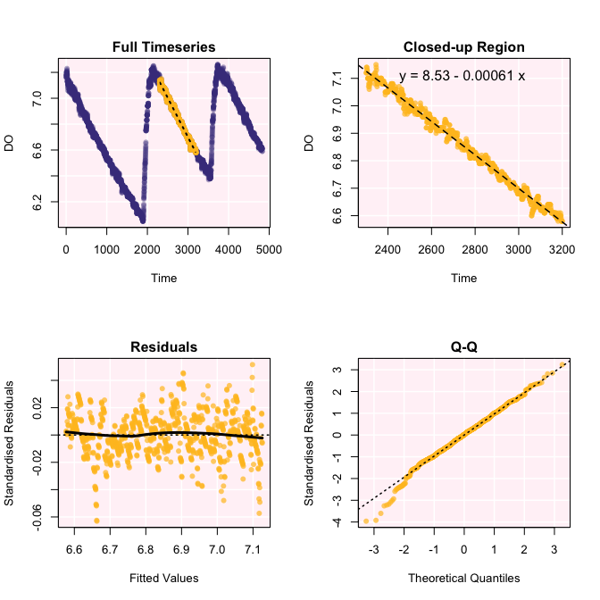

```r
plot(rate, rep = 2)  # view the second subset
```

If background rate is provided, add it as an argument and the results will reflect the correction.

```r
# just showing background-corrected output:
ratebg <- calc.rate(intermittent, from = c(200, 2300, 4100),
  to = c(1800, 3200, 4600), by = 'time', bg = 0.000121, plot = F)
```

```
#> Data subset is by time.
#> Background correction recognised and applied.
#> Result are averaged across 3 data subsets, and weighted to time.
```

```r
ratebg
```

```
#> Background (bg)  : 0.000121
#> Rate (b1)        : -0.000598
#> Adj. Rate (b1-bg): -0.000719
```

Once the rate has been determined, you can calculate the volume- or weight-specific rate using `calc.mo2()`. The `print()` call will list up to 6 regressions and the weighted mean of the results are also given.

```r
# calculate volume-specific rate only (not scaled to weight):
vo2 <- calc.mo2(rate, unit.in = "mg/l/s", unit.out = "mg/h", volume = 1.81)
vo2
```

```
#>           Input    Output
#> 1 -0.0005734109 -3.736345
#> 2 -0.0006097325 -3.973017
#> 3 -0.0006539752 -4.261303
#>
#> Mean (weighted) : -3.894840
#> Input unit : mg/L.o2/sec.time
#> Output unit: mg.o2/hour.time
```

## Further reading

This document provides sample code to analyse a typical intermittent-flow respirometry dataset. For more information about the package, including additional documentation, navigate to the `respR` page on [GitHub](https://github.com/januarharianto/respR). The following vignettes provide additional example workflows based on user needs, and may be useful to you:

1. Maximum, minimum, and interval analyses.
2. Pcrit analyses.

## Code

```r
library(respR)
data(intermittent)
# check the data for errors:
check.input(intermittent, plot = T)

# calculate rate
rate <- calc.rate(intermittent, from = c(200, 2300, 4100),
  to = c(1800, 3200, 4600), by = 'time')
print(rate)
summary(rate)
plot(rate)           # view the first subset
plot(rate, rep = 2)  # view the second subset

# just showing background-corrected output:
ratebg <- calc.rate(intermittent, from = c(200, 2300, 4100),
  to = c(1800, 3200, 4600), by = 'time', bg = 0.000121, plot = F)
ratebg


# calculate volume-specific rate only (not scaled to weight):
vo2 <- calc.mo2(rate, unit.in = "mg/l/s", unit.out = "mg/h", volume = 1.81)
vo2
```